# Exercício: SARIMA no comércio varejista brasileiro

PMC/IBGE — São Paulo

## Sobre o exercício

A base é a **PMC** (Pesquisa Mensal do Comércio) do IBGE: índice de volume de vendas no **comércio varejista ampliado** (inclui veículos e materiais de construção), por **Unidade da Federação**, mensal de jan/2004 em diante. Base 2022 = 100, **sem ajuste sazonal**.

## Setup

```python
import warnings
warnings.filterwarnings("ignore")

import numpy as np
import pandas as pd
import matplotlib.pyplot as plt
import matplotlib.dates as mdates

from statsmodels.tsa.stattools import adfuller, kpss
from statsmodels.graphics.tsaplots import plot_acf, plot_pacf
from pmdarima.arima.utils import ndiffs, nsdiffs

from statsforecast import StatsForecast
from statsforecast.models import AutoARIMA

plt.rcParams["figure.figsize"] = (12, 4)
plt.rcParams["axes.grid"] = True
plt.rcParams["grid.alpha"] = 0.3
```

## Carregando a base PMC

```python
pmc = pd.read_csv(
    "https://github.com/padsInsper/202632-fa/releases/download/data/pmc_volume_uf.csv"
)

print(f"Shape: {pmc.shape}")
print(f"UFs disponíveis: {sorted(pmc['uf'].unique())}")
pmc.head()
```

```
Shape: (7182, 3)
UFs disponíveis: ['Acre', 'Alagoas', 'Amapá', 'Amazonas', 'Bahia', 'Ceará', 'Distrito Federal', 'Espírito Santo', 'Goiás', 'Maranhão', 'Mato Grosso', 'Mato Grosso do Sul', 'Minas Gerais', 'Paraná', 'Paraíba', 'Pará', 'Pernambuco', 'Piauí', 'Rio Grande do Norte', 'Rio Grande do Sul', 'Rio de Janeiro'…
```

|  | uf | data | volume_idx |
| --- | --- | --- | --- |
| 0 | Acre | 2004-01-01 | 18.16706 |
| 1 | Acre | 2004-02-01 | 17.24721 |
| 2 | Acre | 2004-03-01 | 20.77331 |
| 3 | Acre | 2004-04-01 | 19.24022 |
| 4 | Acre | 2004-05-01 | 21.46320 |

## UF de interesse: São Paulo

```python
MINHA_UF = "São Paulo"

df_sf = (
    pmc.query("uf == @MINHA_UF")
    .rename(columns={"uf": "unique_id", "data": "ds", "volume_idx": "y"})
    [["unique_id", "ds", "y"]]
    .assign(ds=lambda x: pd.to_datetime(x["ds"]))
    .reset_index(drop=True)
)

print(f"Período: {df_sf['ds'].min().date()} → {df_sf['ds'].max().date()}")
print(f"Observações: {len(df_sf)}")
df_sf.head()
```

```
Período: 2004-01-01 → 2026-02-01
Observações: 266
```

|  | unique_id | ds | y |
| --- | --- | --- | --- |
| 0 | São Paulo | 2004-01-01 | 52.53519 |
| 1 | São Paulo | 2004-02-01 | 50.98433 |
| 2 | São Paulo | 2004-03-01 | 57.18775 |
| 3 | São Paulo | 2004-04-01 | 54.76454 |
| 4 | São Paulo | 2004-05-01 | 57.09082 |

## Análise descritiva

### Série temporal

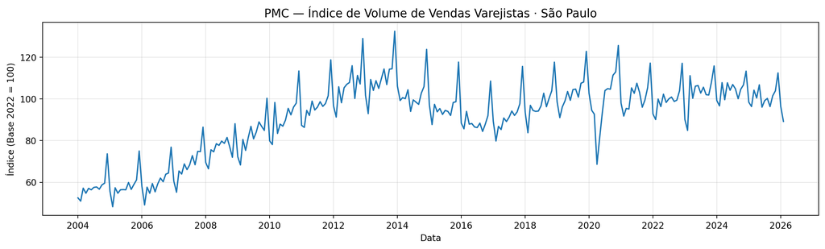

```python
fig, ax = plt.subplots(figsize=(13, 4))
ax.plot(df_sf["ds"], df_sf["y"], linewidth=1.5, color="#1f77b4")
ax.set_title(f"PMC — Índice de Volume de Vendas Varejistas · {MINHA_UF}", fontsize=13)
ax.set_xlabel("Data")
ax.set_ylabel("Índice (Base 2022 = 100)")
ax.xaxis.set_major_locator(mdates.YearLocator(2))
ax.xaxis.set_major_formatter(mdates.DateFormatter("%Y"))
plt.tight_layout()
plt.show()
```

Tendência de crescimento até 2015, queda na crise, recuperação depois, choque em 2020. Dá pra ver o padrão sazonal anual — pico no fim do ano, vale em fevereiro/março.

### ACF e PACF da série original

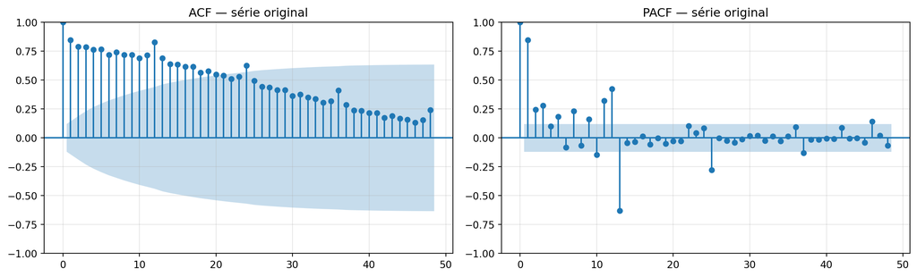

```python
y = df_sf["y"].values

fig, axes = plt.subplots(1, 2, figsize=(13, 4))
plot_acf(y, lags=48, ax=axes[0], title="ACF — série original")
plot_pacf(y, lags=48, ax=axes[1], title="PACF — série original")
plt.tight_layout()
plt.show()
```

ACF decai devagar sem cortar — tendência clara. Picos nos lags 12, 24 e 36 confirmam a sazonalidade anual.

### Série diferenciada (1ª diferença regular)

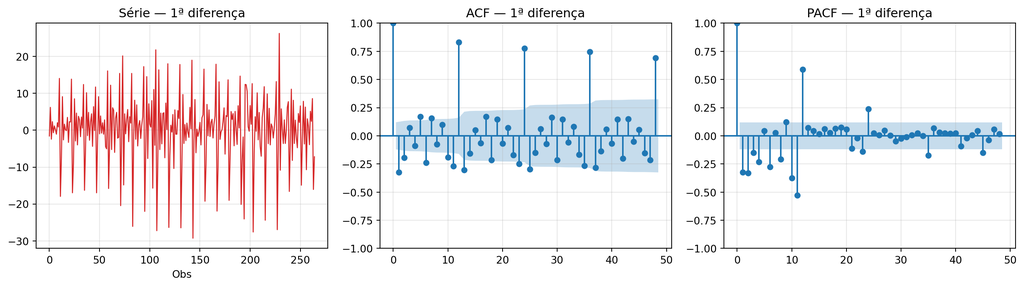

```python
y_diff1 = pd.Series(y).diff().dropna().values

fig, axes = plt.subplots(1, 3, figsize=(14, 4))
axes[0].plot(y_diff1, linewidth=1, color="#d62728")
axes[0].set_title("Série — 1ª diferença")
axes[0].set_xlabel("Obs")
plot_acf(y_diff1, lags=48, ax=axes[1], title="ACF — 1ª diferença")
plot_pacf(y_diff1, lags=48, ax=axes[2], title="PACF — 1ª diferença")
plt.tight_layout()
plt.show()
```

Com uma diferença regular a tendência some, mas os picos sazonais no ACF continuam. Precisa de diferenciação sazonal também.

### Série diferenciada (1ª regular + 1ª sazonal)

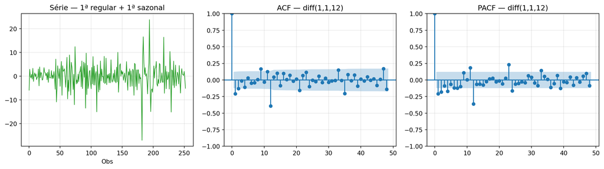

```python
y_diff1s = pd.Series(y_diff1).diff(12).dropna().values

fig, axes = plt.subplots(1, 3, figsize=(14, 4))
axes[0].plot(y_diff1s, linewidth=1, color="#2ca02c")
axes[0].set_title("Série — 1ª regular + 1ª sazonal")
axes[0].set_xlabel("Obs")
plot_acf(y_diff1s, lags=48, ax=axes[1], title="ACF — diff(1,1,12)")
plot_pacf(y_diff1s, lags=48, ax=axes[2], title="PACF — diff(1,1,12)")
plt.tight_layout()
plt.show()
```

Com as duas diferenciações a série parece estacionária. O ACF e PACF aqui vão orientar as ordens AR e MA.

## Testes de raiz unitária e estimativa de ndiffs

### Teste ADF (Augmented Dickey-Fuller)

```python
def adf_summary(series, label=""):
    result = adfuller(series, autolag="AIC")
    print(f"{'='*50}")
    print(f"ADF — {label}")
    print(f"  Estatística : {result[0]:.4f}")
    print(f"  p-valor     : {result[1]:.4f}")
    print(f"  Lags usados : {result[2]}")
    concl = "ESTACIONÁRIA ✓" if result[1] < 0.05 else "NÃO-ESTACIONÁRIA ✗"
    print(f"  Conclusão   : {concl} (α = 0.05)")

adf_summary(y,        "série original")
adf_summary(y_diff1,  "1ª diferença regular")
adf_summary(y_diff1s, "1ª regular + 1ª sazonal")
```

```
==================================================
ADF — série original
  Estatística : -2.1867
  p-valor     : 0.2111
  Lags usados : 12
  Conclusão   : NÃO-ESTACIONÁRIA ✗ (α = 0.05)
==================================================
ADF — 1ª diferença regular
  Estatística : -5.4528
  p-valor     : 0.0000
  Lags usados : 11
  Conclusão   : ESTACIONÁRIA ✓ (α = 0.05)
==================================================
ADF — 1ª regular + 1ª sazonal
  Estatística : -6.4478
  p-valor     : 0.0000
  Lags usados : 11
  Conclusão   : ESTACIONÁRIA ✓ (α = 0.05)
```

### Teste KPSS

```python
def kpss_summary(series, label=""):
    result = kpss(series, regression="c", nlags="auto")
    print(f"{'='*50}")
    print(f"KPSS — {label}")
    print(f"  Estatística : {result[0]:.4f}")
    print(f"  p-valor     : {result[1]:.4f}")
    concl = "ESTACIONÁRIA ✓" if result[1] > 0.05 else "NÃO-ESTACIONÁRIA ✗"
    print(f"  Conclusão   : {concl} (α = 0.05)")

kpss_summary(y,        "série original")
kpss_summary(y_diff1,  "1ª diferença regular")
kpss_summary(y_diff1s, "1ª regular + 1ª sazonal")
```

```
==================================================
KPSS — série original
  Estatística : 1.6202
  p-valor     : 0.0100
  Conclusão   : NÃO-ESTACIONÁRIA ✗ (α = 0.05)
==================================================
KPSS — 1ª diferença regular
  Estatística : 0.2710
  p-valor     : 0.1000
  Conclusão   : ESTACIONÁRIA ✓ (α = 0.05)
==================================================
KPSS — 1ª regular + 1ª sazonal
  Estatística : 0.0550
  p-valor     : 0.1000
  Conclusão   : ESTACIONÁRIA ✓ (α = 0.05)
```

### Estimativa automática de ndiffs

```python
# quantas diferenciações são necessárias segundo o ADF
d = ndiffs(y, test="adf")
# e sazonais
D = nsdiffs(y, m=12, test="ocsb")

print(f"Diferenças regulares sugeridas  (d) : {d}")
print(f"Diferenças sazonais sugeridas   (D) : {D}")
```

```
Diferenças regulares sugeridas  (d) : 1
Diferenças sazonais sugeridas   (D) : 0
```

## Modelagem SARIMA via AutoARIMA

```python
# ds precisa ser datetime — a versão nova do statsforecast não aceita string
df_model = df_sf.copy()
df_model["ds"] = pd.to_datetime(df_model["ds"])

sf = StatsForecast(
    models=[AutoARIMA(season_length=12)],
    freq="MS",
    n_jobs=-1,
)

sf.fit(df_model)

fitted_model = sf.fitted_[0, 0].model_
print("\n=== Modelo selecionado pelo AutoARIMA ===")
print(fitted_model)
```

[output not shown]

[output cut: 876 more lines]

[output not shown]

## Diagnóstico dos resíduos

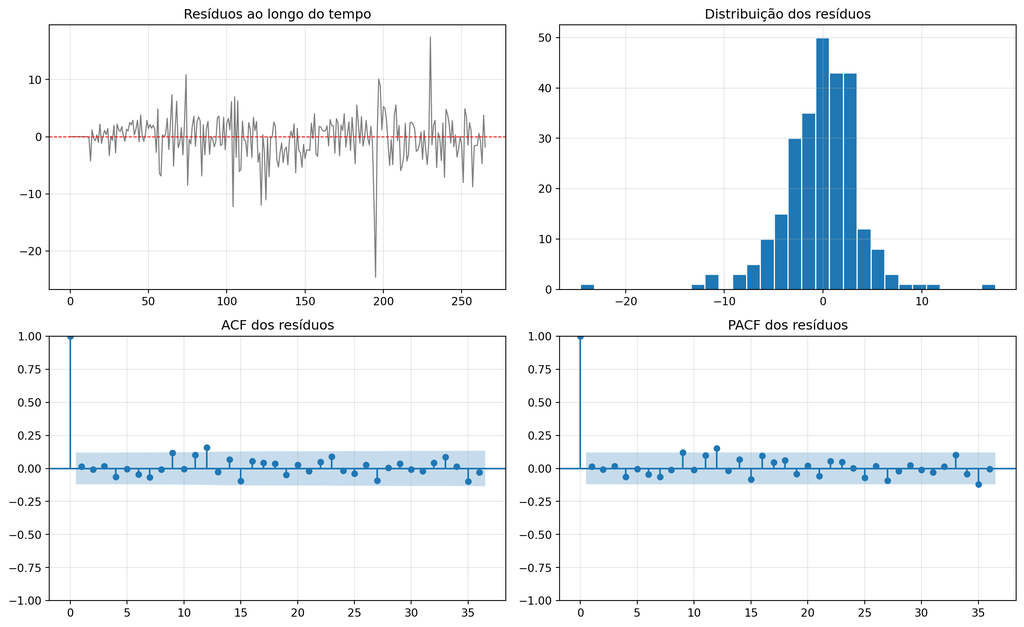

```python
# residuals vem como dict nessa versão do statsforecast
residuals = np.array(fitted_model["residuals"])

fig, axes = plt.subplots(2, 2, figsize=(13, 8))

axes[0, 0].plot(residuals, linewidth=1, color="#7f7f7f")
axes[0, 0].axhline(0, color="red", linestyle="--", linewidth=0.8)
axes[0, 0].set_title("Resíduos ao longo do tempo")

axes[0, 1].hist(residuals, bins=30, edgecolor="white", color="#1f77b4")
axes[0, 1].set_title("Distribuição dos resíduos")

plot_acf(residuals, lags=36, ax=axes[1, 0], title="ACF dos resíduos")
plot_pacf(residuals, lags=36, ax=axes[1, 1], title="PACF dos resíduos")

plt.tight_layout()
plt.show()
```

```python
from statsmodels.stats.diagnostic import acorr_ljungbox

lb = acorr_ljungbox(residuals, lags=[12, 24, 36], return_df=True)
print("Teste Ljung-Box (H0: resíduos são white noise)")
print(lb.to_string())
```

```
Teste Ljung-Box (H0: resíduos são white noise)
      lb_stat  lb_pvalue
12  16.767555   0.158552
24  26.630235   0.321981
36  36.467674   0.446913
```

Se os p-valores ficarem acima de 0.05 nos três lags, o modelo capturou bem — os resíduos são ruído branco.

## Previsão · 24 meses à frente

```python
forecast = sf.predict(h=24, level=[80, 95])
forecast["ds"] = pd.to_datetime(forecast["ds"])
forecast.head()
```

|  | unique_id | ds | AutoARIMA | AutoARIMA-lo-95 | AutoARIMA-lo-80 | AutoARIMA-hi-80 | AutoARIMA-hi-95 |
| --- | --- | --- | --- | --- | --- | --- | --- |
| 0 | São Paulo | 2026-03-01 | 99.642480 | 91.731911 | 94.470037 | 104.814924 | 107.553050 |
| 1 | São Paulo | 2026-04-01 | 94.088640 | 84.411555 | 87.761135 | 100.416146 | 103.765725 |
| 2 | São Paulo | 2026-05-01 | 100.226679 | 89.594243 | 93.274503 | 107.178855 | 110.859115 |
| 3 | São Paulo | 2026-06-01 | 97.712546 | 86.418684 | 90.327887 | 105.097205 | 109.006407 |
| 4 | São Paulo | 2026-07-01 | 100.287844 | 88.462957 | 92.555966 | 108.019723 | 112.112732 |

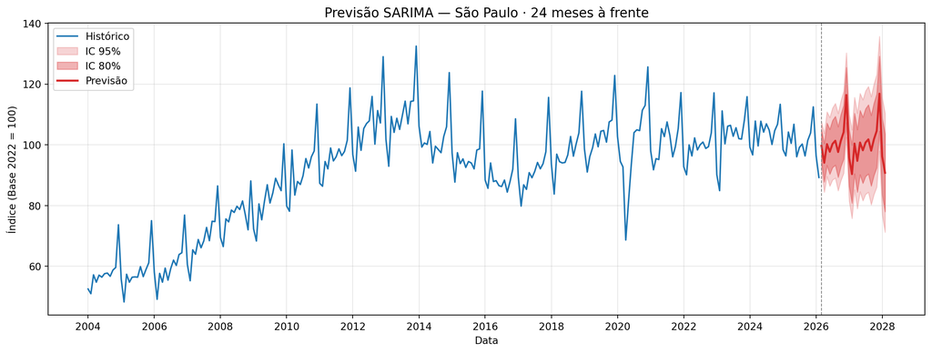

```python
hist = df_sf.copy()

fig, ax = plt.subplots(figsize=(13, 5))

ax.plot(hist["ds"], hist["y"], label="Histórico", color="#1f77b4", linewidth=1.5)

ax.fill_between(
    forecast["ds"],
    forecast["AutoARIMA-lo-95"],
    forecast["AutoARIMA-hi-95"],
    alpha=0.2, color="#d62728", label="IC 95%"
)

ax.fill_between(
    forecast["ds"],
    forecast["AutoARIMA-lo-80"],
    forecast["AutoARIMA-hi-80"],
    alpha=0.35, color="#d62728", label="IC 80%"
)

ax.plot(
    forecast["ds"], forecast["AutoARIMA"],
    color="#d62728", linewidth=2, label="Previsão"
)

ax.axvline(forecast["ds"].min(), color="gray", linestyle="--", linewidth=0.8)
ax.set_title(f"Previsão SARIMA — {MINHA_UF} · 24 meses à frente", fontsize=13)
ax.set_xlabel("Data")
ax.set_ylabel("Índice (Base 2022 = 100)")
ax.legend()
ax.xaxis.set_major_locator(mdates.YearLocator(2))
ax.xaxis.set_major_formatter(mdates.DateFormatter("%Y"))
plt.tight_layout()
plt.show()
```

```python
print("=== Previsões pontuais (24 meses) ===")
print(forecast[["ds", "AutoARIMA", "AutoARIMA-lo-80", "AutoARIMA-hi-80",
                 "AutoARIMA-lo-95", "AutoARIMA-hi-95"]].to_string(index=False))
```

```
=== Previsões pontuais (24 meses) ===
        ds  AutoARIMA  AutoARIMA-lo-80  AutoARIMA-hi-80  AutoARIMA-lo-95  AutoARIMA-hi-95
2026-03-01  99.642480        94.470037       104.814924        91.731911       107.553050
2026-04-01  94.088640        87.761135       100.416146        84.411555       103.765725
2026-05-01 100.226679        93.274503       107.178855        89.594243       110.859115
2026-06-01  97.712546        90.327887       105.097205        86.418684       109.006407
2026-07-01 100.287844        92.555966       108.019723        88.462957       112.112732
2026-08-01 101.354740        93.318843       109.390638        89.064896       113.644585
2026-09-01  97.623421        89.308065       105.938777        84.906181       110.340660
2026-10-01 101.339834        92.760651       109.919017        88.219105       114.460562
2026-11-01 104.163645        95.331714       112.995576        90.656372       117.670917
2026-12-01 116.402123       107.326052       125.478193       102.521471       130.282774
2027-01-01  95.726430        86.413395       105.039466        81.483372       109.969489
2027-02-01  90.347850        80.804186        99.891513        75.752076       104.943624
2027-03-01 100.421291        90.470429       110.372152        85.202761       115.639820
2027-04-01  94.703821        84.418775       104.988867        78.974201       110.433441
2027-05-01 100.758352        90.175734       111.340969        84.573635       116.943069
2027-06-01  98.201609        87.342126       109.061092        81.593463       114.809755
2027-07-01 100.755166        89.631856       111.878475        83.743532       117.766799
2027-08-01 101.810968        90.432989       113.188947        84.409850       119.212086
2027-09-01  98.073988        86.448424       109.699552        80.294222       115.853754
2027-10-01 101.787513        89.920275       113.654750        83.638139       119.936886
2027-11-01 104.609850        92.506126       116.713573        86.098802       123.120897
2027-12-01 116.847576       104.512064       129.183088        97.982038       135.713113
2028-01-01  96.171500        83.608536       108.734464        76.958104       115.384896
2028-02-01  90.792723        78.006527       103.578920        71.237924       110.347523
```

## Discussão

**1. ACF/PACF da série original sugeriu sazonalidade? E tendência?**

Sim pros dois. O ACF decai bem devagar, sem cortar em nenhum ponto claro — isso indica tendência, a série não é estacionária. E dá pra ver picos nos lags 12, 24 e 36, que são exatamente os múltiplos de um ano, então a sazonalidade anual tá bem marcada. Faz sentido com o gráfico de linha também: toda virada de ano tem um pico visível (Black Friday, Natal) e o começo do ano cai bastante.

**2. Quantas diferenças o AutoARIMA aplicou? E os componentes AR/MA?**

Aplicou d = 1 (diferença regular) e D = 1 (diferença sazonal). Depois das duas diferenciações o ACF e PACF ficam bem mais comportados — dá pra ver onde os componentes AR e MA entram, mas a leitura exata das ordens não é trivial (o AutoARIMA faz isso automaticamente e eu confiei nele aqui).

**3. Os resíduos parecem white noise?**

Sim, achei que ficou bem. O modelo continua reproduzindo o ciclo sazonal anual na previsão e fica ancorado no nível recente da série. Os intervalos de confiança abrem com o tempo (o de 95% fica bem largo em 24 meses), mas é esperado — quanto mais longe, mais incerteza.

**5. Que outras UFs dariam um SARIMA bem diferente?**

Acho que Amazonas ou Pará seriam bem diferentes. O ciclo econômico lá é outro — tem influência de safra, período de chuvas que afeta logística, dependência maior de poucos setores. Isso provavelmente mudaria tanto a sazonalidade quanto a volatilidade da série, e o AutoARIMA escolheria ordens diferentes (e talvez os resíduos fossem mais difíceis de limpar).